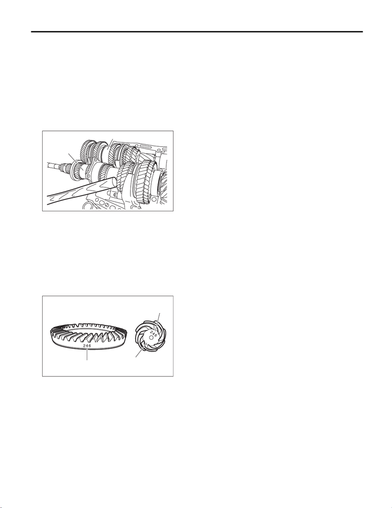

6MT(TY75)-92

Drive Pinion Shaft Assembly

MANUAL TRANSMISSION AND DIFFERENTIAL

17.Drive Pinion Shaft Assembly

A: REMOVAL

1) Remove the manual transmission assembly from the vehicle. <Ref. to 6MT(TY75)-25, REMOVAL, Manual

Transmission Assembly.>

2) Remove the transfer case together with the extension case assembly. <Ref. to 6MT(TY75)-51, REMOV-

AL, Transfer Case and Extension Case Assembly.>

3) Remove the transmission case. <Ref. to 6MT(TY75)-79, REMOVAL, Transmission Case.>

4) Remove the drive pinion shaft assembly.

NOTE:

Use a hammer handle, etc. to remove if too tight.

5) Remove the main shaft assembly.

B: INSTALLATION

1) Remove the front differential assembly.

2) Hypoid gear set match mark/No.: The number (A) on top of the drive pinion, and the number on the hypoid

driven gear are set numbers for the two gears. Use a pair having the same numbers.

The figure (B) below shows a number for shim adjustment. If no number is shown, the value is zero.

3) Place the drive pinion shaft assembly on transmission main case RH without shim and tighten the bearing

mounting bolts.

MT-01877

(A)

(B)

(A) Main shaft ASSY

(B) Drive pinion shaft ASSY

MT-00990

(A)

(B)

(A)

+0.1

(A) Set number

(B) Number for shim adjustment

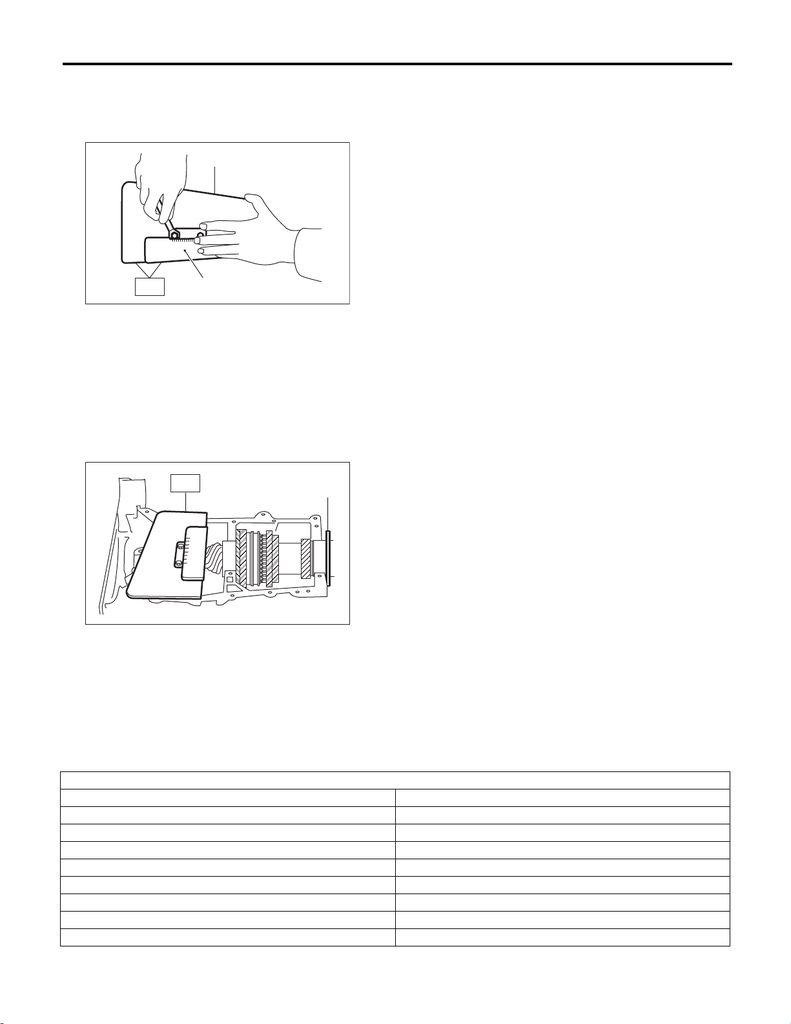

6MT(TY75)-93

Drive Pinion Shaft Assembly

MANUAL TRANSMISSION AND DIFFERENTIAL

4) Perform the adjustment of ST.

(1) Loosen the two bolts and adjust so that the scale indicates 0.5 correctly when the plate end and the

scale end are on the same level.

ST 499917500 DRIVE PINION GAUGE ASSY

(2) Tighten the two bolts.

5) Position the ST by inserting the knock pin of ST into the knock hole of transmission case.

ST 499917500 DRIVE PINION GAUGE ASSY

6) Slide the drive pinion gauge scale with finger tip and read the value at the point where it matches with the

end face of drive pinion.

ST 499917500 DRIVE PINION GAUGE ASSY

7) The thickness of shim shall be determined by adding the value indicated on drive pinion to the value indicat-

ed on the ST. (Add if the number on drive pinion is prefixed by +, and subtract if the number is prefixed by –.)

8) Select one to three shims in the following table for the value determined as described above, and take the

shim(s) whose thickness is closest to the said value.

NOTE:

Install the shim with it's cut in facing the shifter fork & rod side.

MT-00242

(A)

(B)

ST

(A) Plate

(B) Scale

MT-01880

(A)

ST

(A) Adjust the clearance to zero without shim.

Drive pinion shim

Part No. Thickness mm (in)

32295AA031 0.150 (0.0059)

32295AA041 0.175 (0.0069)

32295AA051 0.200 (0.0079)

32295AA061 0.225 (0.0089)

32295AA071 0.250 (0.0098)

32295AA081 0.275 (0.0108)

32295AA091 0.300 (0.0118)

32295AA101 0.500 (0.0197)

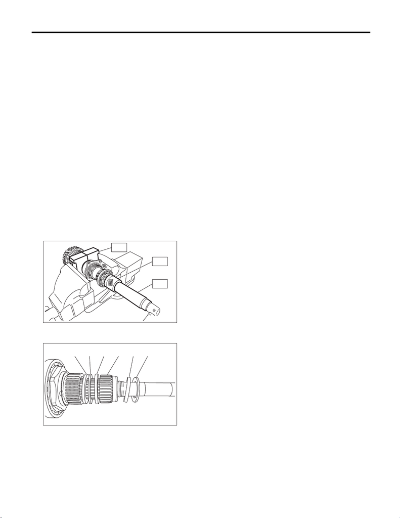

6MT(TY75)-94

Drive Pinion Shaft Assembly

MANUAL TRANSMISSION AND DIFFERENTIAL

9) Install the front differential assembly. <Ref. to 6MT(TY75)-112, INSTALLATION, Front Differential Assem-

bly.>

10) Fit the transmission case knock pin to the knock pin hole of the roller bearing and install the drive pinion

shaft assembly.

11) Install the main shaft assembly. <Ref. to 6MT(TY75)-83, INSTALLATION, Main Shaft Assembly for Sin-

gle-Range.>

12) Check each shifter fork. <Ref. to 6MT(TY75)-140, INSPECTION, Shifter Fork and Rod.>

13) Install the transmission case. <Ref. to 6MT(TY75)-80, INSTALLATION, Transmission Case.>

14) Install the transfer case together with the extension case assembly. <Ref. to 6MT(TY75)-53, INSTALLA-

TION, Transfer Case and Extension Case Assembly.>

15) Install the manual transmission assembly to the vehicle. <Ref. to 6MT(TY75)-30, INSTALLATION, Man-

ual Transmission Assembly.>

C: DISASSEMBLY

NOTE:

• Attach a cloth to the end of driven shaft (on the frictional side of the thrust needle bearing) to prevent dam-

age during disassembly or reassembly.

• When replacing the coupling sleeve and synchronizer hub, replace them as a set. Because these must en-

gage at the specified point, avoid disassembly as much as possible. If it is necessary to disassemble, mark

the engaging points on the splines beforehand.

1) Flatten the tab of the lock nut.

2) Remove the lock nut using ST1, ST2 and ST3.

ST1 18680AA020 HOLDER

ST2 18667AA020 HOLDER

ST3 18662AA010 SOCKET WRENCH (27)

3) Remove the lock washer, washer, differential bevel gear sleeve, adjusting washer No. 1, thrust bearing

and adjusting washer No. 2.

MT-02494

ST1

ST3

ST2

MT-02495

(A)(B)(C)(D)(E)(F)

(A) Lock washer

(B) Washer

(C) Differential bevel gear sleeve

(D) Adjusting washer No. 1 (25 × 36 × t)

(E) Thrust bearing (25 × 36 × 2)

(F) Adjusting washer No. 2 (25 × 36 × t)

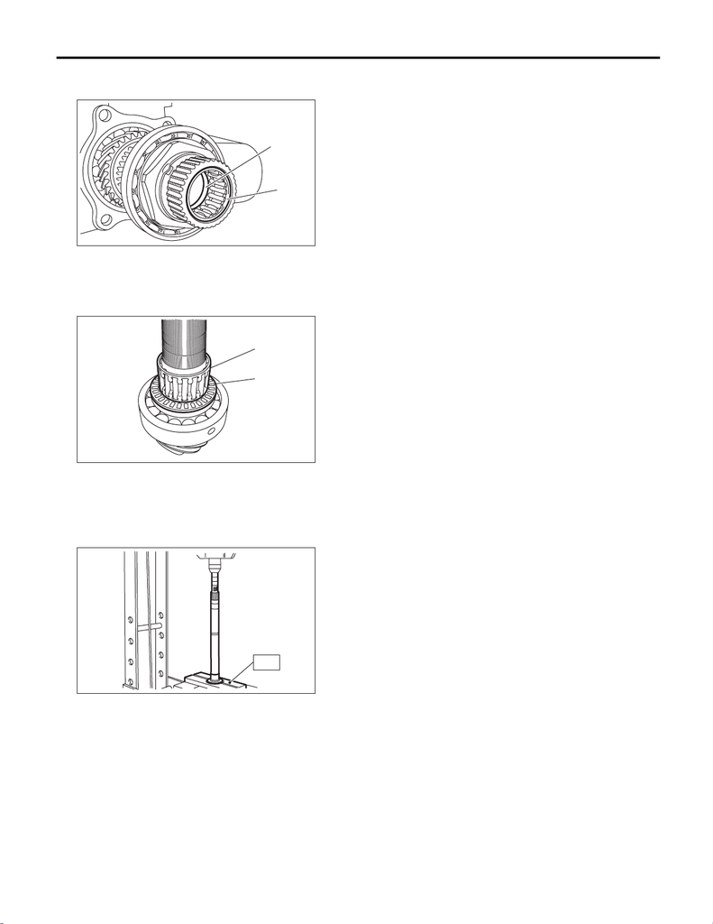

6MT(TY75)-95

Drive Pinion Shaft Assembly

MANUAL TRANSMISSION AND DIFFERENTIAL

4) Draw out the drive pinion shaft from driven shaft.

5) Remove the needle bearing and drive pinion collar.

6) Remove the needle bearing and thrust bearing.

7) Remove the roller bearing and washer using ST and a press.

ST 498077000 REMOVER

8) Flatten the tab of the lock nut.

MT-02496

(A)

(B)

(A) Drive pinion collar

(B) Needle bearing (25 × 30 × 20)

MT-02497

(A)

(B)

(A) Needle bearing (30 × 37 × 23)

(B) Thrust bearing (33 × 50 × 3)

MT-01943

ST

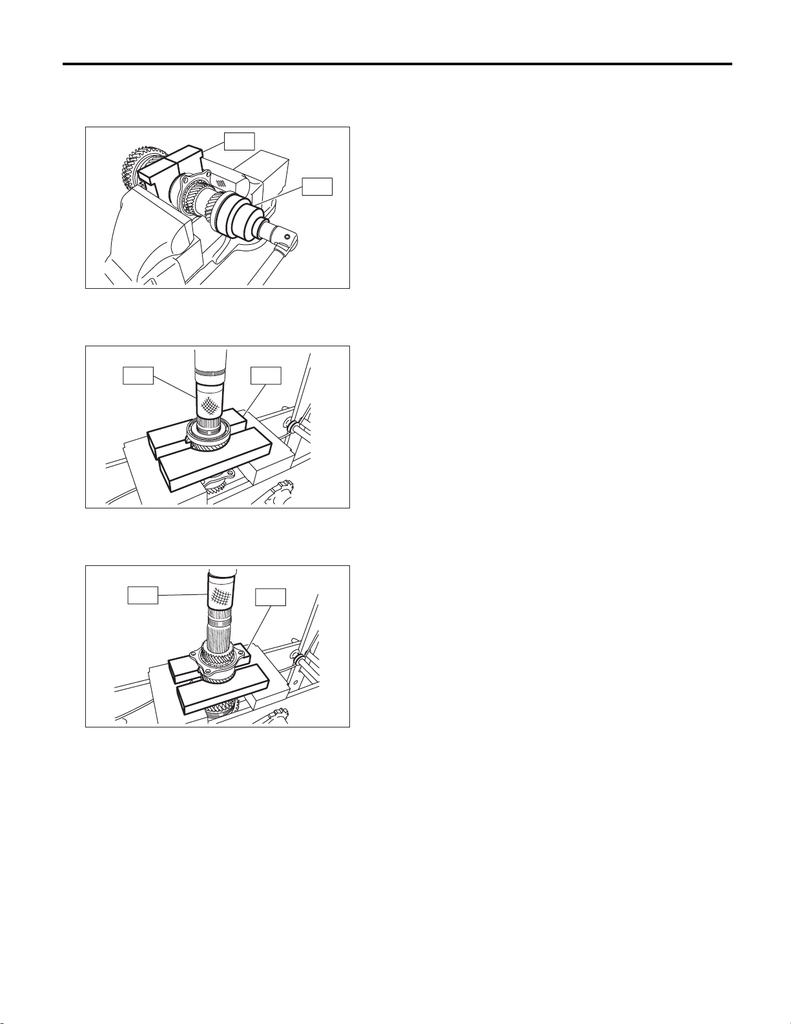

6MT(TY75)-96

Drive Pinion Shaft Assembly

MANUAL TRANSMISSION AND DIFFERENTIAL

9) Remove the lock nut using ST1 and ST2.

ST1 499987300 SOCKET WRENCH (50)

ST2 18680AA020 HOLDER

10) Remove the ball bearing, 6th driven gear and drive pinion spacer using the ST1, ST2 and a press.

ST1 899754112 PRESS

ST2 899714110 REMOVER

11) Remove the 5th driven gear, double ball bearing and 3rd-4th driven gear using ST1, ST2 and a press.

ST1 899754112 PRESS

ST2 899714110 REMOVER

12) Remove the key.

13) Remove the 2nd driven gear, 2nd inner baulk ring, 2nd synchro cone, 2nd outer baulk ring, 1st-2nd shift-

ing insert and 1st-2nd coupling sleeve.

CAUTION:

When removing 1st-2nd coupling sleeve, be careful not to lose the 1st-2nd shifting insert.

MT-02498

ST2

ST1

MT-02499

ST1 ST2

MT-02500

ST1

ST2

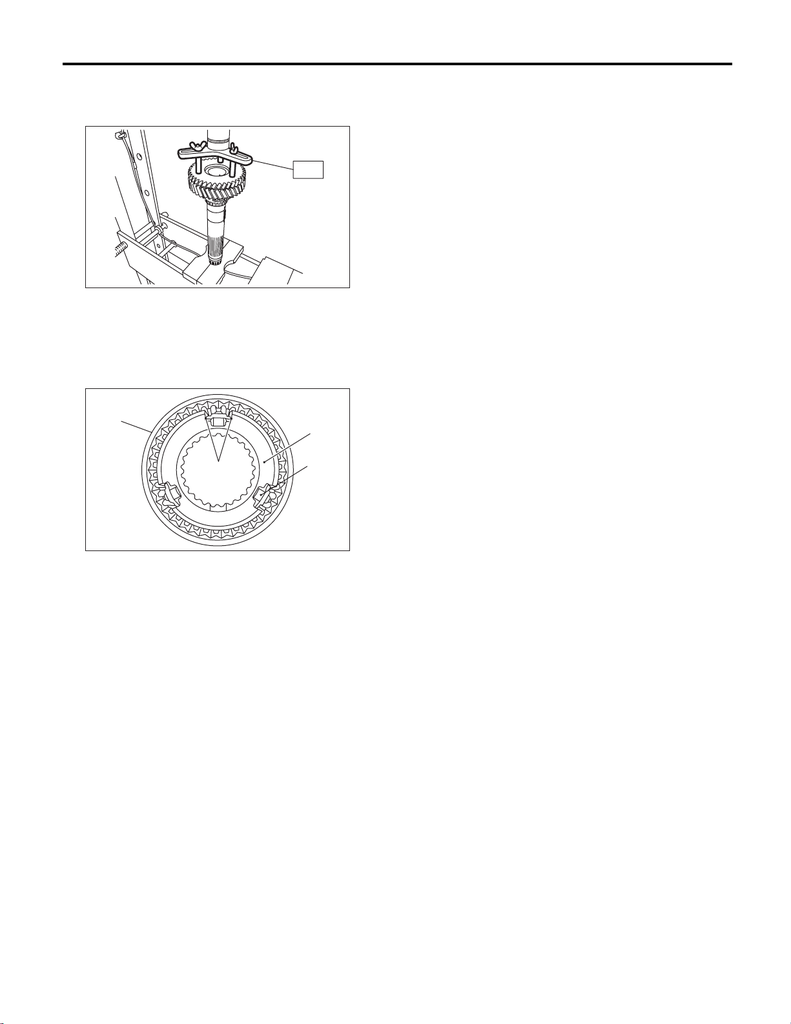

6MT(TY75)-97

Drive Pinion Shaft Assembly

MANUAL TRANSMISSION AND DIFFERENTIAL

14) Remove the 1st driven gear, 1st inner baulk ring, 1st synchro cone, 1st outer baulk ring, 2nd driven gear

bushing and 1st-2nd synchronizer hub using ST and a press.

ST 18762AA001 COMPRESSOR SPECIAL TOOL

D: ASSEMBLY

NOTE:

• Match the alignment marks, and install the coupling sleeve to the synchronizer hub and then install the

shifting insert.

• Make sure that there is no large clearance at both sides of the shifting insert after assembly.

MT-02501

ST

MT-02542

(A)

(B)

(C)

(D)

(A) Shifting insert

(B) Synchronizer hub

(C) Coupling sleeve

(D) There is no large clearance at this part.

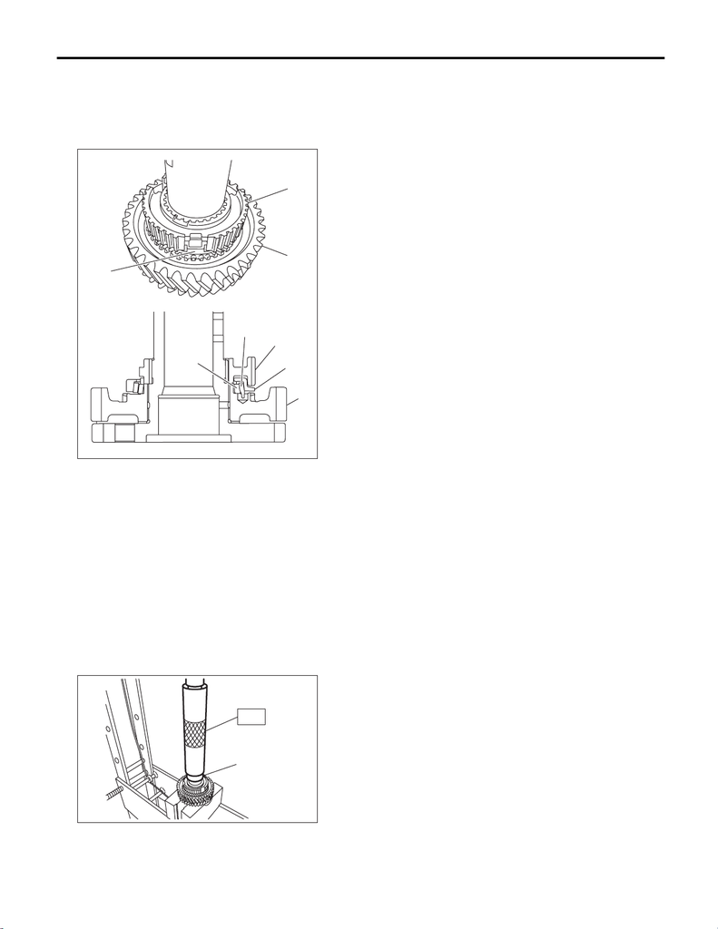

6MT(TY75)-98

Drive Pinion Shaft Assembly

MANUAL TRANSMISSION AND DIFFERENTIAL

1) Install the 1st driven gear, 1st inner baulk ring, 1st synchro cone, 1st outer baulk ring and 1st-2nd synchro-

nizer hub.

NOTE:

• Install the 1st-2nd synchronizer hub in proper direction.

• Align the protrusion of the outer baulk ring into the groove of the 1st-2nd synchronizer hub.

2) Install the 2nd driven gear bushing using ST and a press.

CAUTION:

Do not apply a load in excess of 10 kN (1 ton, 1.1 US ton, 1.0 Imp ton).

NOTE:

• Attach a cloth to the end of the driven shaft to prevent damage.

• When press fitting, align the oil holes of the driven shaft and 2nd driven gear bushing.

ST 18654AA000 INSTALLER

MT-02502

(E)

(A)

(E)

(C)

(B)

(D)

(A)

(D)

(A) 1st driven gear

(B) 1st inner baulk ring

(C) 1st synchro cone

(D) 1st outer baulk ring

(E) 1st-2nd synchronizer hub

(A)

ST

MT-02503

(A) 2nd driven gear bushing

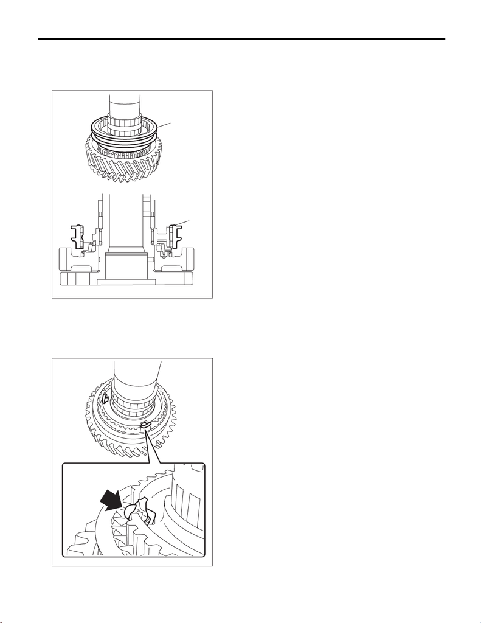

6MT(TY75)-99

Drive Pinion Shaft Assembly

MANUAL TRANSMISSION AND DIFFERENTIAL

3) Install the 1st-2nd coupling sleeve.

NOTE:

• Install the 1st-2nd coupling sleeve in proper direction.

• Align the alignment marks of 1st-2nd coupling sleeve and the 1st-2nd synchronizer hub.

4) Install the 1st-2nd shifting insert.

NOTE:

Press in the ball part to install.

MT-02696

(A)

(A)

(A) 1st-2nd coupling sleeve

MT-02505

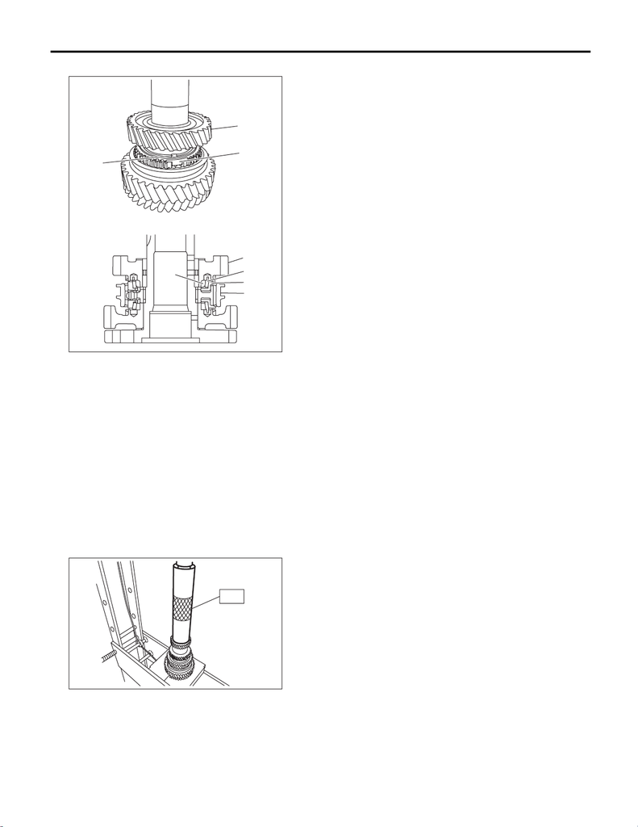

6MT(TY75)-100

Drive Pinion Shaft Assembly

MANUAL TRANSMISSION AND DIFFERENTIAL

5) Install the 2nd outer baulk ring, 2nd synchro cone, 2nd inner baulk ring and 2nd driven gear.

6) Install the key to the driven shaft.

7) Using the ST and a press, install the 3rd-4th driven gear.

CAUTION:

Do not apply a load in excess of 10 kN (1 ton, 1.1 US ton, 1.0 Imp ton).

NOTE:

• Match the groove on the 3rd-4th driven gear to the key.

• Install the 3rd-4th driven gear in the proper direction.

ST 499277200 INSTALLER

MT-02697

(A)

(E)

(A)

(D)

(C)

(D)

(C)

(B)

(A) 2nd driven gear

(B) 2nd inner baulk ring

(C) 2nd synchro cone

(D) 2nd outer baulk ring

(E) 1st-2nd coupling sleeve

ST

MT-02507

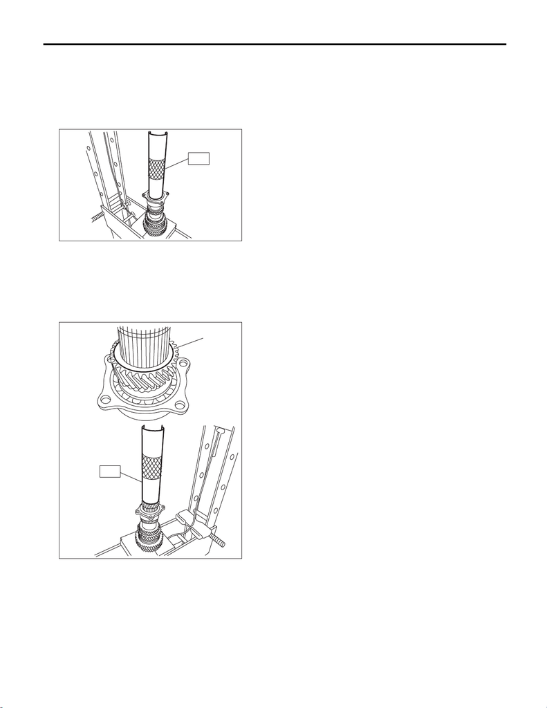

6MT(TY75)-101

Drive Pinion Shaft Assembly

MANUAL TRANSMISSION AND DIFFERENTIAL

8) Using the ST and a press, install the double ball bearing.

CAUTION:

Do not apply a load in excess of 10 kN (1 ton, 1.1 US ton, 1.0 Imp ton).

NOTE:

Use a new double ball bearing.

ST 499277200 INSTALLER

9) Install the 5th driven gear using ST and press.

CAUTION:

Do not apply a load in excess of 10 kN (1 ton, 1.1 US ton, 1.0 Imp ton).

NOTE:

Install the 5th driven gear with the groove side facing the 6th driven gear.

ST 499277200 INSTALLER

10) Install the drive pinion spacer to the driven shaft.

ST

MT-02508

ST

(A)

MT-02509

(A) Install with the groove side facing the 6th driven gear.

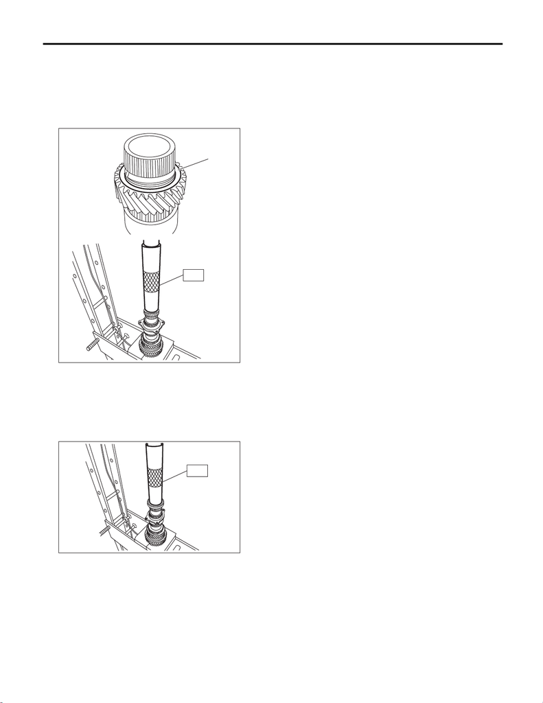

6MT(TY75)-102

Drive Pinion Shaft Assembly

MANUAL TRANSMISSION AND DIFFERENTIAL

11) Install the 6th driven gear using ST and press.

CAUTION:

Do not apply a load in excess of 10 kN (1 ton, 1.1 US ton, 1.0 Imp ton).

NOTE:

Install with the stepped side on the end surface of the 6th driven gear facing the rear ball bearing side.

ST 499277200 INSTALLER

12) Using the ST and a press, install the ball bearing.

CAUTION:

Do not apply a load in excess of 10 kN (1 ton, 1.1 US ton, 1.0 Imp ton).

ST 499277200 INSTALLER

ST

(A)

MT-02510

(A) Install with the stepped side facing the rear ball bearing.

ST

MT-02511

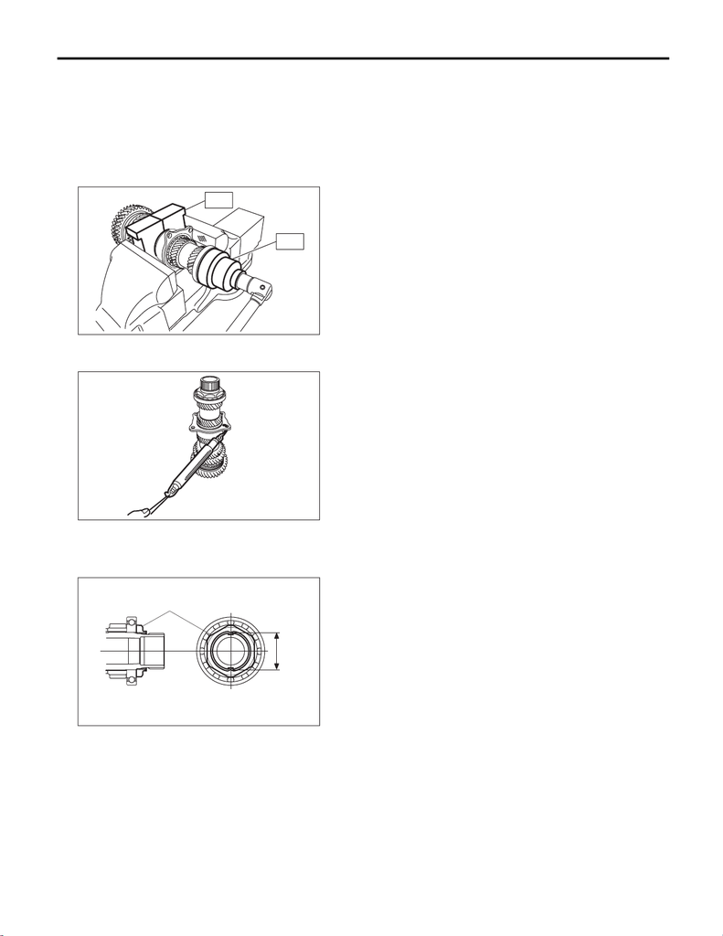

6MT(TY75)-103

Drive Pinion Shaft Assembly

MANUAL TRANSMISSION AND DIFFERENTIAL

13) Install the lock nut using ST1 and ST2.

NOTE:

Use a new lock nut.

Tightening torque:

440 N·m (44.9 kgf-m, 324.5 ft-lb)

ST1 499987300 SOCKET WRENCH (50)

ST2 18680AA020 HOLDER

14) Using a spring scale, check that starting load of the ball bearing is 0.1 to 1.5 N (0.01 to 0.15 kgf, 0.02 to

0.34 lbf).

15) Crimp the lock nut at two locations so that the dimension (B) becomes 39.1 mm (1.54 in) or less.

CAUTION:

When crimping the lock nut, be careful not to crack it.

MT-02498

ST2

ST1

MT-01953

MT-02703

(B)

(A)

(A) Lock nut

(B) Outer dimension after crimping

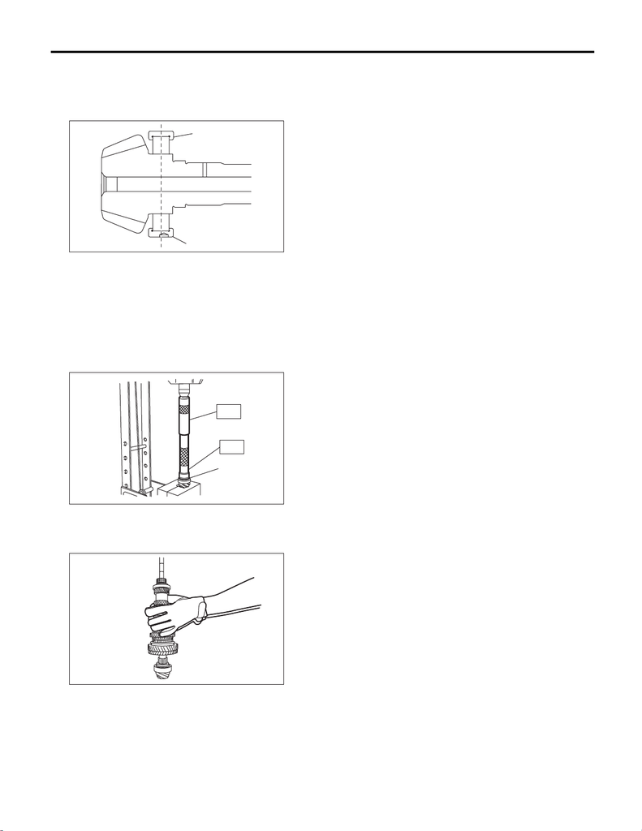

6MT(TY75)-104

Drive Pinion Shaft Assembly

MANUAL TRANSMISSION AND DIFFERENTIAL

16) Install the roller bearing.

NOTE:

• Use a new roller bearing.

• Install with the knock pin hole of the roller bearing outer race facing the rear side.

17) Install the washer using ST1, ST2 and a press.

CAUTION:

Do not apply a load in excess of 10 kN (1 ton, 1.1 US ton, 1.0 Imp ton).

ST1 499277100 BUSHING 1-2 INSTALLER

ST2 499277200 INSTALLER

18) Install the thrust bearing and needle bearing and install the driven shaft assembly.

MT-01965

(A)

(B)

(A) Roller bearing

(B) Knock pin hole

MT-01954

(A)

ST1

ST2

(A) Washer

MT-01955

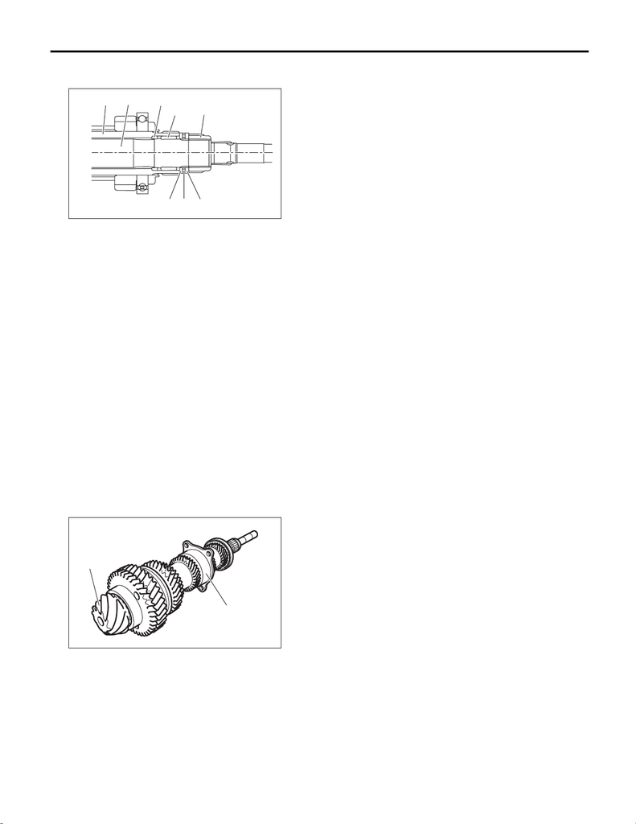

6MT(TY75)-105

Drive Pinion Shaft Assembly

MANUAL TRANSMISSION AND DIFFERENTIAL

19) Install the drive pinion collar, needle bearing, adjusting washer No. 2, thrust bearing, adjusting washer

No. 1 and differential bevel gear sleeve in this order.

20) Adjust the thrust bearing preload. <Ref. to 6MT(TY75)-107, THRUST BEARING PRELOAD, ADJUST-

MENT, Drive Pinion Shaft Assembly.>

E: INSPECTION

Disassembled parts should be washed with cleaning solvent first, then inspected.

1) Bearing

Replace the bearings in the following cases.

• When the bearing balls, outer races and inner races are broken or rusty.

• When the bearing is worn.

• When the bearings fail to turn smoothly or emit noise in rotation after gear oil lubrication.

• The double ball bearing of the drive pinion shaft should be checked for smooth rotation before the drive

pinion shaft assembly is disassembled. In this case, because a preload is working on the bearing, its rotation

feels like it is slightly dragging unlike other bearings.

• When bearing has other defects.

(E)

(A) (B) (C)

(D) (H)

(F) (G)

MT-02512

(A) Driven shaft

(B) Drive pinion shaft

(C) Drive pinion collar

(D) Needle bearing (25 × 30 × 20)

(E) Adjusting washer No. 2 (25 × 36 × t)

(F) Thrust bearing (25 × 36 × 2)

(G) Adjusting washer No. 1 (25 × 36 × t)

(H) Differential bevel gear sleeve

MT-01884

(A)

(B)

(A) Drive pinion shaft

(B) Double ball bearing

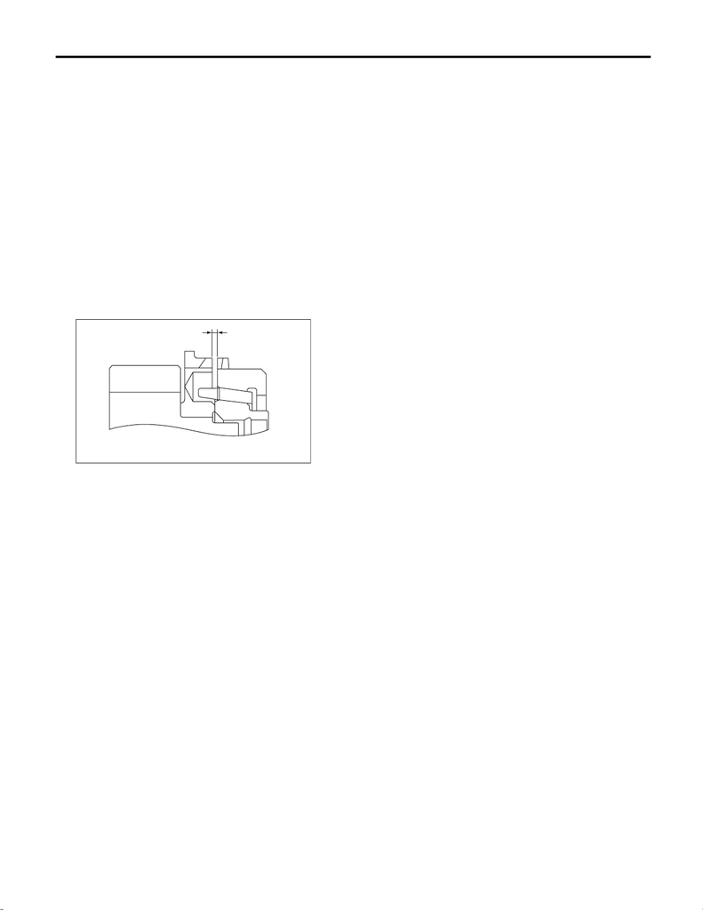

6MT(TY75)-106

Drive Pinion Shaft Assembly

MANUAL TRANSMISSION AND DIFFERENTIAL

2) Bushing (each gear)

Replace the bushing in following cases.

• When the sliding surface is damaged or abnormally worn.

• When the inner wall is abnormally worn.

3) Gear

Replace gears in the following cases.

• Replace the gear with new part if its tooth surfaces are broken, damaged or excessively worn.

• Correct or replace if the cone that contacts the baulk ring is rough or damaged.

• Correct or replace if the inner surface or end face is damaged.

4) Baulk ring, synchro cone

Replace the baulk ring and synchro cone in the following cases.

• When the inner surface and end face are damaged.

• When the baulk ring inner surface is abnormally or partially worn down.

• If the gap between the end faces of the baulk ring and the gear splined part is excessively small, check the

clearance (A) while pressing the ring against the cone.

Clearance (A):

0.5 mm (0.020 in) or more

• When the contact surface of the baulk ring insert section is damaged or abnormally worn.

• Apply gear oil to the cone of the gear and while press-fitting the baulk ring, check there is no rotation in the

circumferential direction.

5) Coupling sleeve and synchronizer hub

• Check the slipping condition of the coupling sleeve.

• Check the splines on the coupling sleeve and synchronizer hub for wear.

MT-01674

(A)

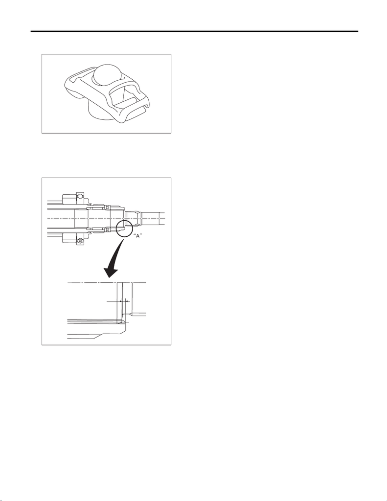

6MT(TY75)-107

Drive Pinion Shaft Assembly

MANUAL TRANSMISSION AND DIFFERENTIAL

6) Shifting insert

Replace the shifting insert if there is deformation, excessive wear on the ball section or any defectiveness.

F: ADJUSTMENT

1. THRUST BEARING PRELOAD

1) Select a suitable adjusting washer No. 1 so that dimension (H) will be zero in a visual check. Position the

washer (20 × 31 × 4) and lock washer (20 × 31 × 2.3) and attach the lock nut (20 × 11).

MT-02493

MT-02513

(H)

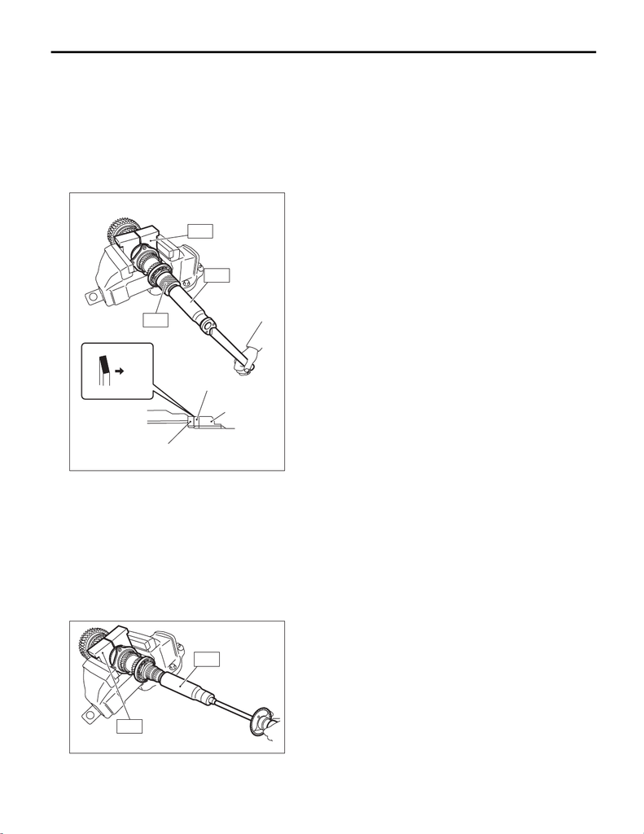

6MT(TY75)-108

Drive Pinion Shaft Assembly

MANUAL TRANSMISSION AND DIFFERENTIAL

2) Install the lock nut with ST1, ST2 and ST3.

NOTE:

• Use new lock nuts and lock washers.

• Install the lock washer in the correct direction.

Tightening torque:

126 N·m (12.8 kgf-m, 92.9 ft-lb)

ST1 18680AA020 HOLDER

ST2 18667AA020 HOLDER

ST3 18662AA010 SOCKET (27)

3) After removing the ST2 used in step 2), measure the starting torque using torque driver.

Starting torque:

0.3 — 0.8 N·m (0.03 — 0.08 kgf-m, 0.2 — 0.6 ft-lb)

ST1 18680AA020 HOLDER

ST3 18662AA010 SOCKET (27)

ST1

ST2

ST3

(A)

(B)

(C)

MT-02780

(D)

(A) Lock nut

(B) Lock washer

(C) Washer

(D) Lock nut side

MT-01886

ST1

ST3

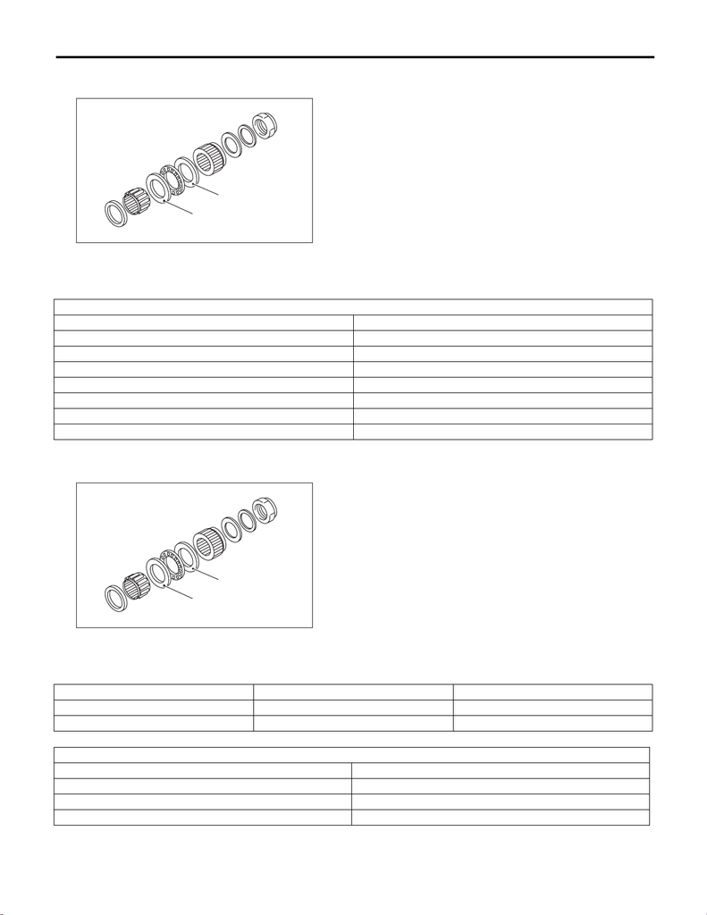

6MT(TY75)-109

Drive Pinion Shaft Assembly

MANUAL TRANSMISSION AND DIFFERENTIAL

4) If the starting torque is not within the specified limit, select new adjusting washer No. 1 and recheck start-

ing torque.

5) If the specified starting torque cannot be obtained by the selection of adjusting washer No. 1, select ad-

justing washer No. 2 from the list below. Repeat steps 1) through 4) to adjust starting torque.

MT-02514

(A)

(B)

(A) Adjusting washer No. 1

(B) Adjusting washer No. 2

Adjusting washer No. 1

Part No. Thickness mm (in)

803025071 2.925 (0.1152)

803025072 2.950 (0.1161)

803025073 2.975 (0.1171)

803025074 3.000 (0.1181)

803025075 3.025 (0.1191)

803025076 3.050 (0.1201)

803025077 3.075 (0.1211)

MT-02514

(A)

(B)

(A) Adjusting washer No. 1

(B) Adjusting washer No. 2

Starting torque Dimension H Adjusting washer No. 2

Low Small Select thicker one.

High Large Select thinner one.

Adjusting washer No. 2

Part No. Thickness mm (in)

803025070 2.850 (0.1122)

803025074 3.000 (0.1181)

803025078 3.150 (0.1240)

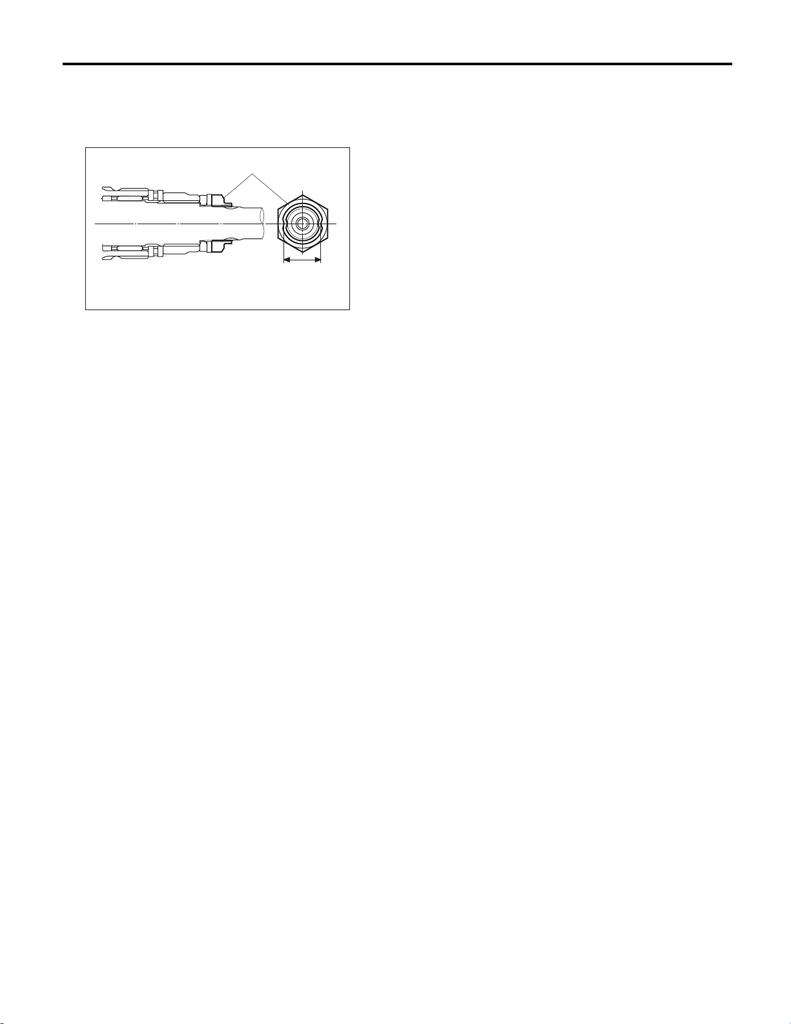

6MT(TY75)-110

Drive Pinion Shaft Assembly

MANUAL TRANSMISSION AND DIFFERENTIAL

6) Recheck that the starting torque is within the specified range, and crimp the lock nut at two locations so

that the dimension (B) becomes 20.1 mm (0.79 in) or less.

CAUTION:

When crimping the lock nut, be careful not to crack it.

MT-02704

(B)

(A)

(A) Lock nut

(B) Outer dimension after crimping